# The Elo method in chess

**Elo method** was coined by the physics professor and excellent chess player Arpad Elo. In 1970, FIDE, the World Chess Federation, agreed to adopt the Elo Rating System.

The method works as follows. Suppose that players $i$ and $j$ match. Let $s_{i,j}$ be the **actual score** of $i$ in the match against $j$. We have that:

- $s_{i,j} = 1$ if $i$ wins;
- $s_{i,j} = 0$ if $i$ loses; and
- $s_{i,j} = 0.5$ if there is a draw.

Notice that the actual score $s_{j,i}$ of $j$ in the match against $i$ is $1 - s_{i,j}$. Let $\mu_{i,j}$ be the **expected score** of $i$ in the match against $j$. We have that:

$$\begin{array}{lll}
\mu_{i,j} & = & \frac{1}{1 + 10^{-(r_i - r_j) / \zeta}} =
\frac{10^{r_i / \zeta}}{10^{r_i / \zeta} + 10^{r_j / \zeta}} \\\\
\end{array}$$

with $r_i$ and $r_j$ the ratings of $i$ and $j$ before the match and $\zeta$ is a constant. Notice that the expected score $\mu_{j,i}$ of $j$ in the match against $i$ is $1 - \mu_{i,j}$.

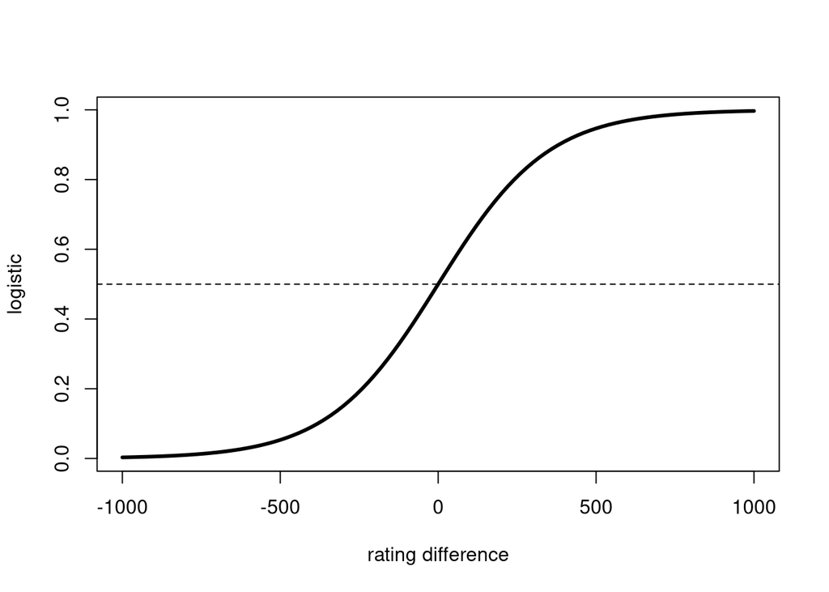

We assume that initially all player ratings are equal to 0. When players $i$ and $j$ match, the new ratings $r_i$ of $i$ and $r_j$ of $j$ are modified using the following update rule:

$$\begin{array}{lll}
r_{i} & \leftarrow & r_i + \kappa (s_{i,j} - \mu_{i,j})
\\
r_j & \leftarrow & r_j + \kappa (s_{j,i} - \mu_{j,i})
\end{array}$$

where $\kappa$ is a constant.

The Elo thesis is:

> *If a player performs as expected, it gains nothing. If it performs better than expected, it is rewarded, while if it performs poorer than expected, it is penalized.*

This challenge is ispired by [Chess ratings - Elo versus the Rest of the World](https://www.kaggle.com/c/chess#description) Kaggle competition.

## Downloads

- A CSV with outcomes of 65053 distinct chess games (White, Black and Score). The possible values for Score represent the three possible outcomes of a chess game (1=White wins, 0.5=draw, 0=Black wins). Read [details](https://www.kaggle.com/c/chess/data).

```r
library(dplyr)

games = read.csv("data.csv")
str(games)
```

```
## 'data.frame':    65053 obs. of  3 variables:
##  $ White: int  73 73 73 73 73 88 88 88 154 158 ...
##  $ Black: int  1246 5097 5104 7321 7375 1033 1860 4858 3377 8059 ...
##  $ Score: num  0.5 0.5 0.5 1 0.5 0.5 1 1 0 1 ...
```

## Challenges

### Question 1

Has the White an advantage over the Black, that is, is there a first-mover advantage?

```r
outcomes = games |>
  mutate(Score = factor(Score, levels = c(0, 0.5, 1),
                        labels = c("Black wins", "Draw", "White wins"))) |>
  count(Score) |>
  mutate(share = n / sum(n))
outcomes
```

```
##        Score     n     share
## 1 Black wins 15224 0.2340246
## 2       Draw 28666 0.4406561
## 3 White wins 21163 0.3253194
```

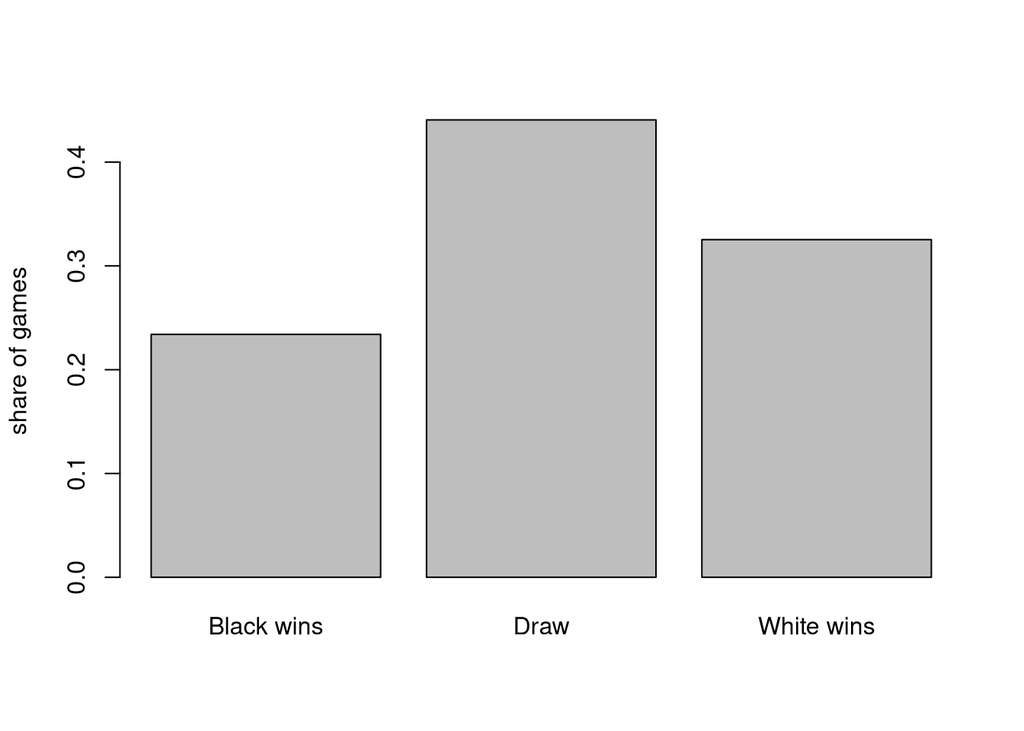

```r
barplot(outcomes$share, names.arg = outcomes$Score, ylab = "share of games")
```

### Answer Yes, White seems to have an advantage. White wins 32.5% of the games and Black 23.4%, while 44.1% are draws. This could be related to white moving first, but the data alone can’t prove it: we only know outcomes while other data about the games could be useful for this kind of assumption.

### Question 2

Write a function that computes the player point rating (1 point for wins, 0.5 points for draws, 0 points for defeats). How are point ratings distributed? Why?

```r
point_rating = function(games) {
  bind_rows(
    games |> mutate(player = White, points = Score),
    games |> mutate(player = Black, points = 1 - Score)
  ) |>
    group_by(player) |>
    summarise(points = sum(points), games = n())
}

points = point_rating(games)
summary(points$points)
```

```
##    Min. 1st Qu.  Median    Mean 3rd Qu.    Max.
##    0.00    1.00    3.00    8.91    9.00  167.50
```

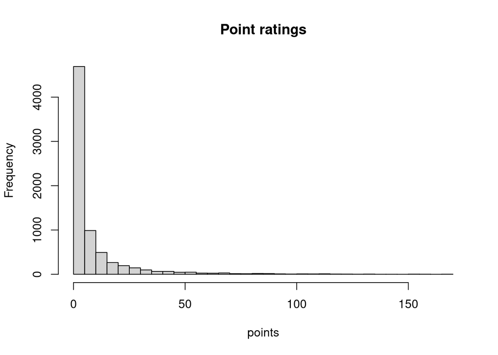

```r
hist(points$points, breaks = 30, main = "Point ratings", xlab = "points")
```

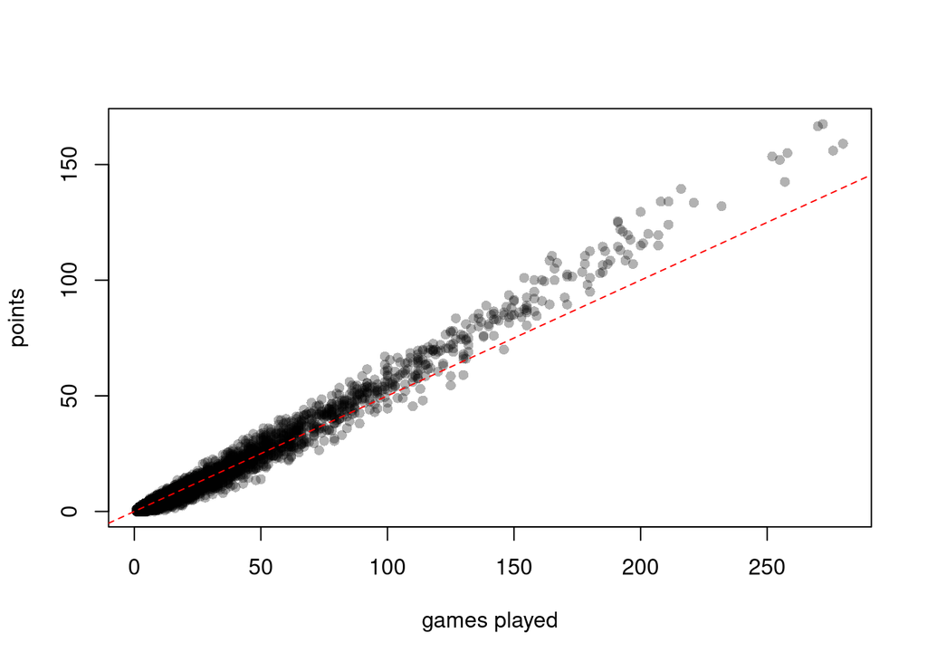

```r
plot(points$games, points$points, pch = 16, col = rgb(0, 0, 0, 0.3), xlab = "games played", ylab = "points")
abline(0, 0.5, col = "red", lty = 2)
```

### Answer Most players have few points and a few have very many. The reason is that the number of games differs a lot between players. Most players play few games, so they cannot collect many points, and a few play hundreds. Points and games played are heavily correlated (as seen in the second graph), so the point rating mostly measures how much someone played, not how well.

### Question 3

An interesting property of Elo’s ratings is that the sum of all player ratings is always 0. Formally show this property. (Hint: use the fact that $s_{i,j} + s_{j,i}=1$ and $\mu_{i,j} + \mu_{j,i} =1$)

### Answer

Base case. All ratings start at 0, so $\sum_k r_k = 0$.

Step. Suppose the sum is 0 before a match between $i$ and $j$. The match changes only $r_i$ and $r_j$:

$$\begin{array}{lll}
\Delta r_i + \Delta r_j & = & \kappa (s_{i,j} - \mu_{i,j}) +
\kappa (s_{j,i} - \mu_{j,i}) \\
& = & \kappa \left[ (s_{i,j} + s_{j,i}) - (\mu_{i,j} +
\mu_{j,i}) \right] \\
& = & \kappa (1 - 1) = 0
\end{array}$$

since $s_{i,j} + s_{j,i} = 1$ and $\mu_{i,j} + \mu_{j,i} = 1$.

So every match leaves the total unchanged. The sum was 0 at the start, so it will be 0 after any number of matches.

In words: whatever rating one player gains, the opponent loses, so the total never changes.

### Question 4

Write a function that computes the player Elo rating (set $\zeta = 400$ and $\kappa = 25$) (Hint: take advantage of the 0-sum property to optimize the code). Observe its distribution: why is it different from the point distribution? Verify the 0-sum property for Elo’s ratings

```r
elo_rating = function(games, zeta = 400, kappa = 25) {
  ratings = rep(0, max(games$White, games$Black))
  for (g in 1:nrow(games)) {
    w = games$White[g]
    b = games$Black[g]
    mu = 1 / (1 + 10^(-(ratings[w] - ratings[b]) / zeta))
    delta = kappa * (games$Score[g] - mu)
    ratings[w] = ratings[w] + delta
    ratings[b] = ratings[b] - delta
  }
  ratings
}

ratings = elo_rating(games)
players = sort(unique(c(games$White, games$Black)))
elo = data.frame(player = players, elo = ratings[players])

summary(elo$elo)
```

```
##     Min.  1st Qu.   Median     Mean  3rd Qu.     Max.
## -146.456  -22.873   -6.005    0.000   12.476  326.950
```

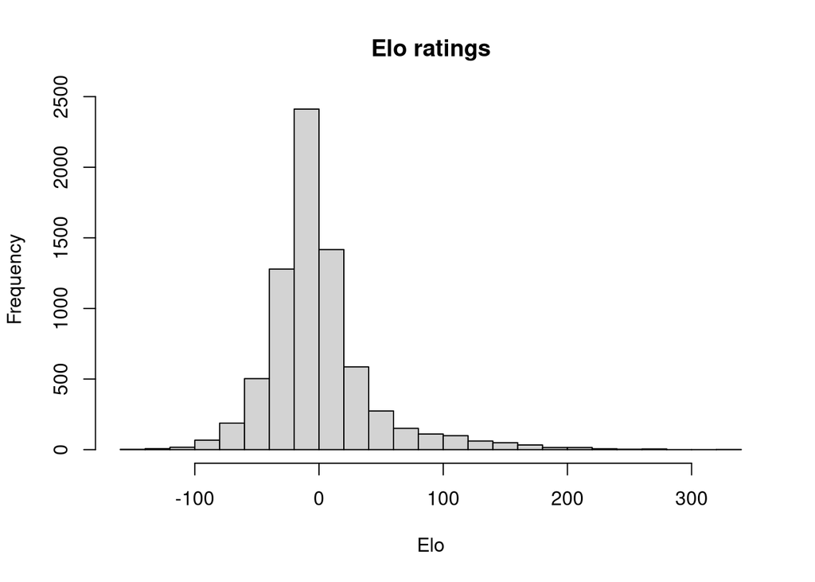

```r
hist(elo$elo, breaks = 30, main = "Elo ratings", xlab = "Elo")
```

```r
sum(ratings)   # 0-sum
```

```
## [1] 9.049983e-13
```

### Answer

Elo ratings are centred around 0, with most players close to it and a few strong players far above (up to about +300). Point ratings, instead, mostly count games played, so they pile up near 0 with a long tail. Elo rewards only the difference between actual and expected results. A player who played many games but scored as expected stays near 0. Beating strong opponents raises the rating and losing to weak ones lowers it, so ratings spread around 0 (both negatively and positively) instead of growing with the number of games. `sum(ratings)` is 9e-13, which is 0 up to rounding error.

### Question 5

Are point and Elo ratings correlated? Are top Elo players overlapping with top point players?

```r
points$elo = elo$elo   # same player order in both tables
cor(points$points, points$elo)
```

```
## [1] 0.7198872
```

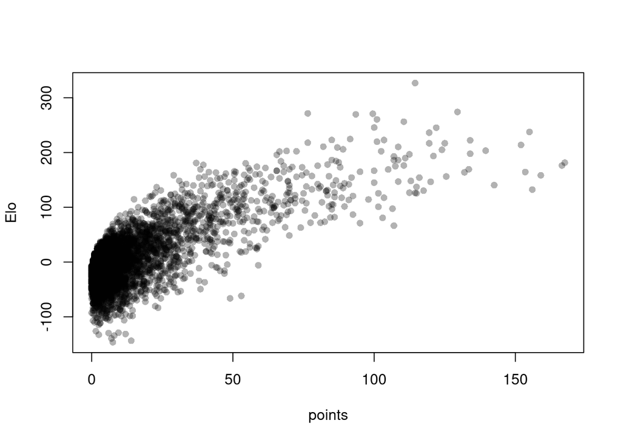

```r
plot(points$points, points$elo, pch = 16, col = rgb(0, 0, 0, 0.3),
     xlab = "points", ylab = "Elo")
```

```r
top_points = points |> arrange(desc(points)) |> head(100)
top_elo = points |> arrange(desc(elo)) |> head(100)
inner_join(top_points, top_elo, by = "player") |> nrow()
```

```
## [1] 53
```

### Answer

Yes, but only to some extent: the correlation is 0.72. Players with many points tend to have a high Elo, but the relation isn’t strict. Points count how many games a player played, while Elo counts how well they did against their opponents. The top players overlap only partially: of the top 100 by points, 53 are also in the top 100 by Elo. It’s important to state, though, that both this and the previous answer are given by assuming that the game results in the csv file are in chronological order.

### Question 6

Test if the number of played games has an effect on the Elo and point player ratings

```r
cor(points$games, points$points)
```

```
## [1] 0.9900841
```

```r
cor(points$games, points$elo)
```

```
## [1] 0.6387939
```

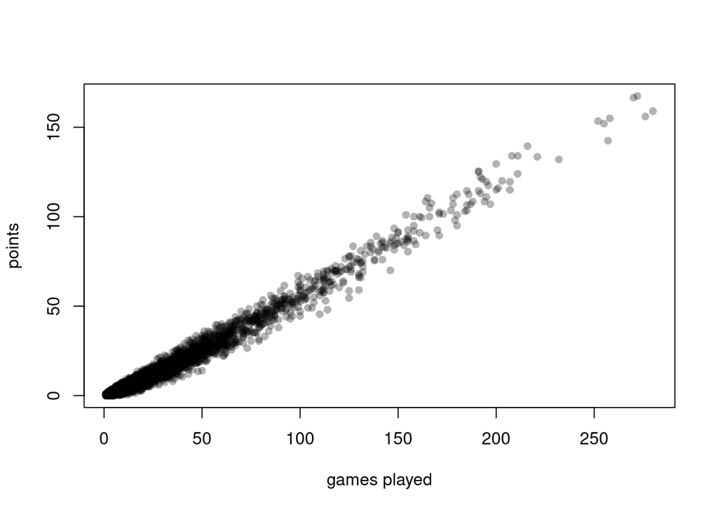

```r
plot(points$games, points$points, pch = 16, col = rgb(0, 0, 0, 0.3),
     xlab = "games played", ylab = "points")
```

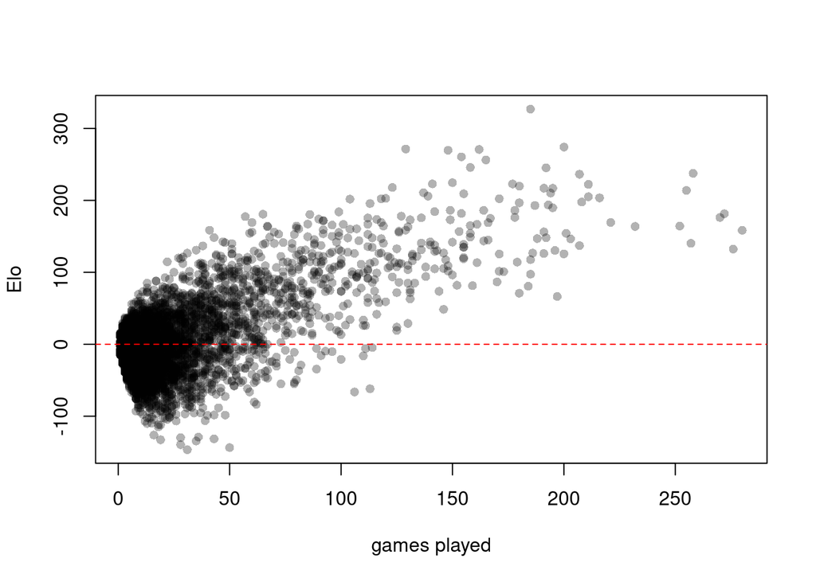

```r
plot(points$games, points$elo, pch = 16, col = rgb(0, 0, 0, 0.3),
     xlab = "games played", ylab = "Elo")
abline(h = 0, col = "red", lty = 2)
```

### Answer Yes, the number of games has an effect on both, but a different one. For points there’s almost a perfect relation: each game adds points, so the correlation is 0.99. For Elo the effect is weaker (correlation 0.64) and not guaranteed: players with few games stay close to 0, while players with many games spread out, and the ones who play the most tend to have a high Elo. Playing a lot doesn’t raise the Elo by itself. The likely reason is that good players keep playing, and their rating needs many games to move far from 0, so more games also means more room to win or lose rating.